# Data Analysis And Data Modeling

Pavan Akula

*RDBMS Prespective*

### Data Analysis - Starts with Data

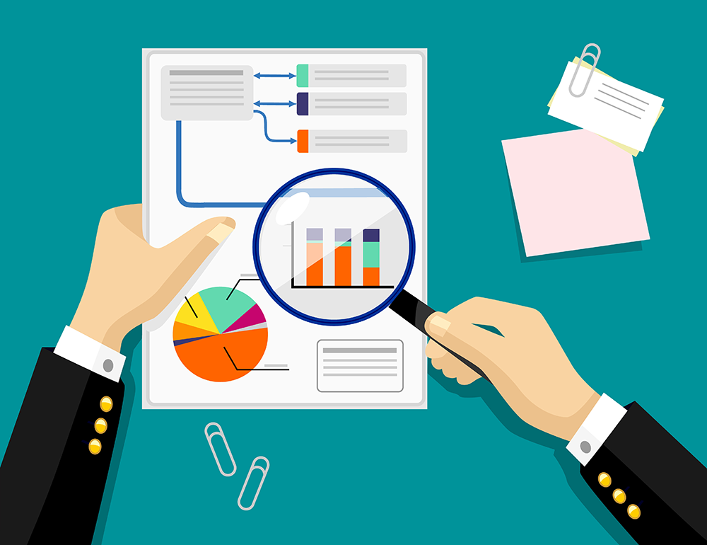

Data can often be represented or abstracted as an `{n x d}` data matrix, with n rows and d columns. Rows may be referred to as entities, instances, records, transactions, tuples, and so on. On the other hand, columns may be called attributes, properties, features, dimensions, variables, fields.

### Data Analysis - Business needs

- Data Analysis is set of tools and techniques.
- Discovering insightful, interesting, and novel patterns.
- Descriptive, understandable, and predictive models.
- Pattern mining, clustering, classification, and forecasting.

*Data Analysis leads to Information.*

### Data Modeling - Managing data

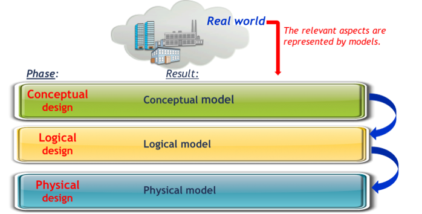

Data modeling is a set of tools and techniques to understand and analyze how to collect, update and store data. Traditionally Data Models used in practice falls into three categories.

### Data Modeling - Concepts

- Conceptual data models aka *Domain models.*
- Logical data models describe *entity types and attributes* and relationships between the entities.
- Physical data models aka *Database.* All the object that make up the database including schemas, tables, and columns.

*Data Modeling ends with collecting and managing data.*

### Data Modeling - Big Picture

- Conceptual data model, give broad description about the businenss needs. Facts or things needed to conduct business.
- It represents how business is done in real world.
- Should be able to be understood by Business users.
- It typically describes an entire enterprise and its business concepts.
- It's highly abstract in nature, often used on strategic data projects.
- Customer, Product, Store, Location, Asset.

### Data Modeling - Big Picture

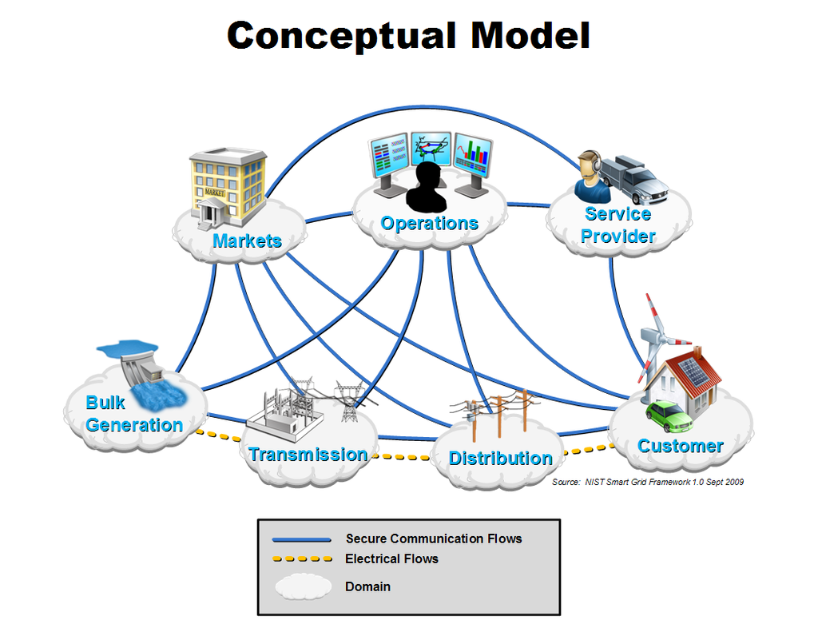

### Data Modeling - Digging deeper

- A logical data model is a fully-attributed data model that is independent of DBMS.
- Data attributes are well established, datatypes with precisions and lengths assigned.
- Entities and attributes will have definitions.
- Logical models are created using information gathered from business requirements.
- This is a bridge between the Conceptual data model and Physical data model.

### Data Modeling - Digging deeper

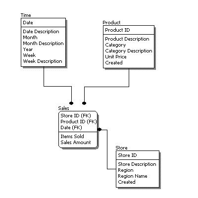

### Data Modeling - Detail Oriented

- Physical data model represents the actual design blueprint of a relational database.
- Represents how data should be structured and related in a specific database
- Accurate use of data type is needed for entity columns.
- Based on RDBMS reserved words has to be avoided in naming entities and columns.
- Primary keys, foreign keys, and constraints are well defined.

### Data Modeling - Detail Oriented

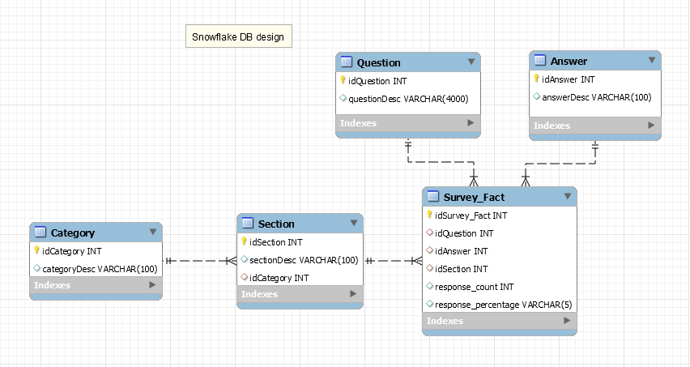

### Data Modeling - Jargon

Database Functional Implementation

- OLTP - Online transaction processing system
- CRM - Customer resourse management system
- ERP - Enterprise resourse planning system
- OLAP - Online analitical processing
- Star Schema
- Snowflake Schema

Major RDBMS

- Oracle
- MS SQL Server
- SAP Sybase Anywhere
- MySQL
- IBM DB2

### Case - Study

Pew Research Center and Smithsonian magazine conducted a national survey *U.S. Views of Technology and the Future* which asked Americans about a wide range of potential scientific developments from near-term advances like robotics and bioengineering, to more “futuristic” possibilities like teleportation or space colonization. More information can be found at http://www.pewinternet.org/2014/04/17/us-views-of-technology-and-the-future/. PDF file *Feb_2014_Views_Future_Crosstab.pdf,* will be used to demonstrate relation between Data Analysis and Data Modeling.

### Scope and Requirements

- This is crosstab report.
- Business Analyst needs partial data.
- For the scope of the presentation partial report is used.
- Data needs to be stored in the RDBMS database.
- Showcase Star Schema and Snowflake Schema.

### Star Schema - Crow's Foot Cardinality Notation

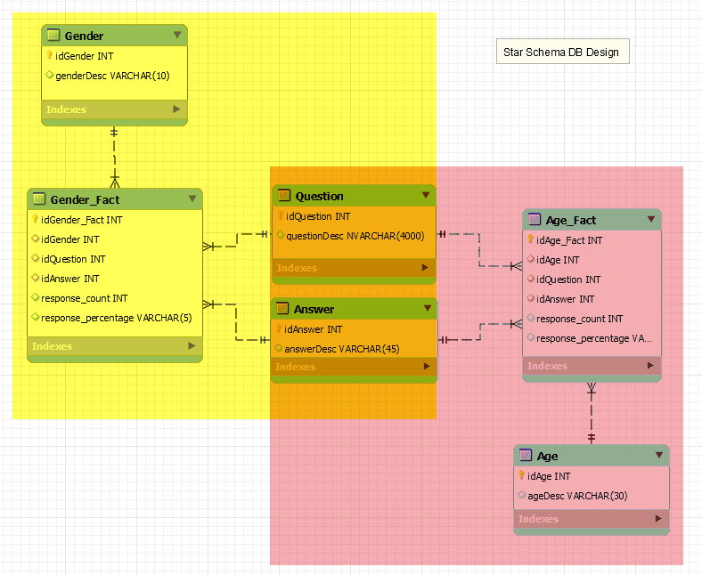

### Database - Tables

[figure not shown]

### Star Schema - Question table

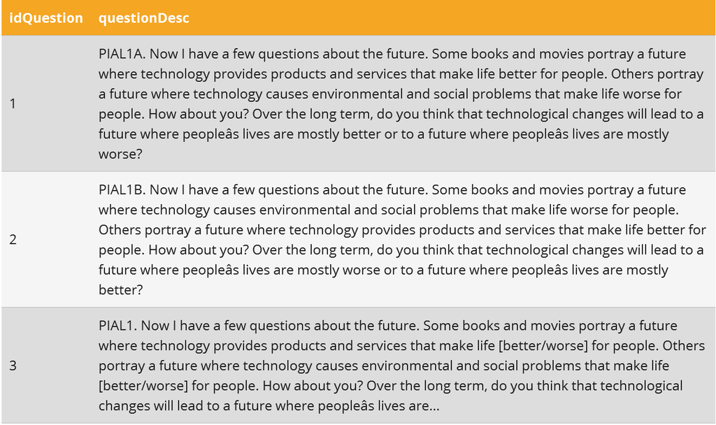

### Star Schema - Answer table

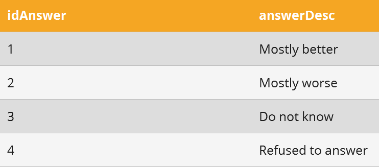

### Star Schema - Age table

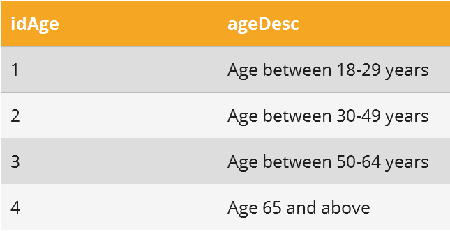

### Star Schema - Age fact table

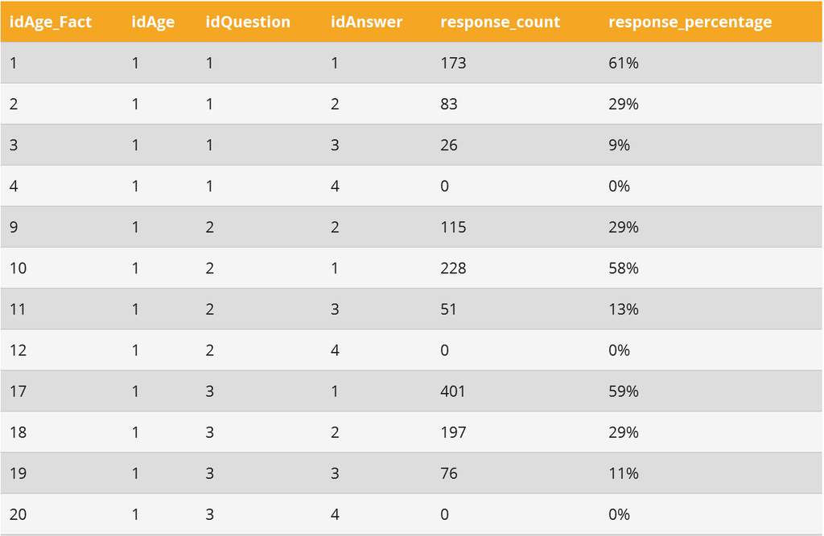

### Snowflake Schema - Crow's Foot Cardinality Notation

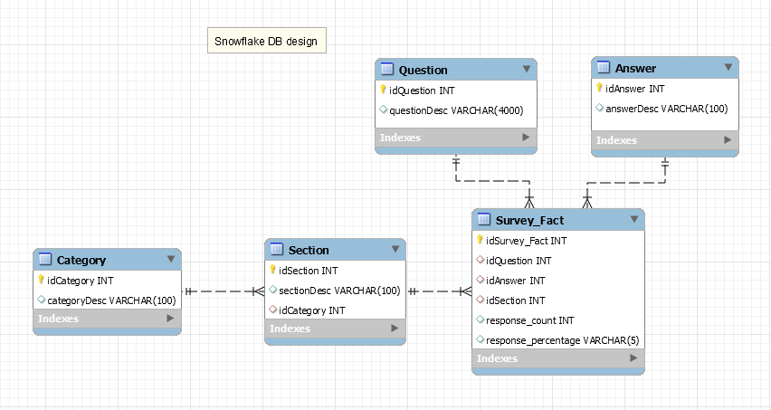

### Snowflake Schema - Section table

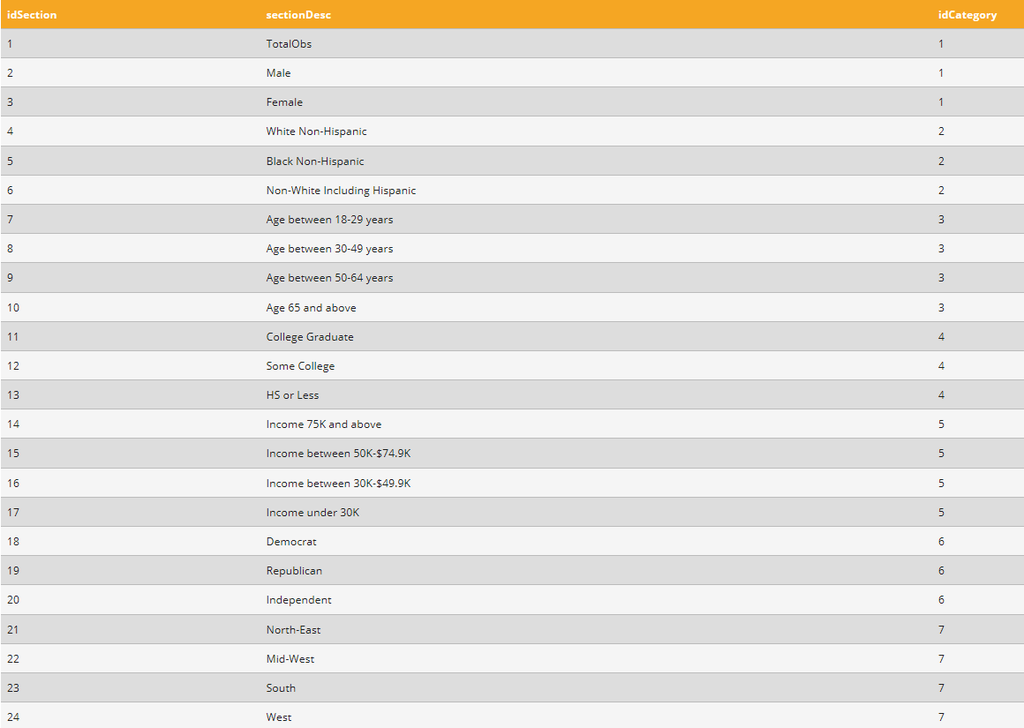

### Snowflake Schema - Category table

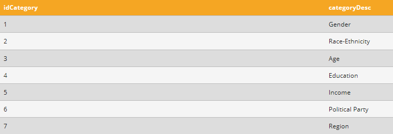

### Snowflake Schema - Survey Fact table

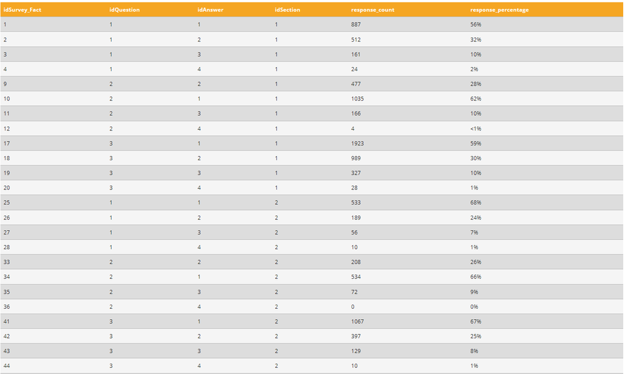

### Snowflake Schema - Classic Cardinality Notation

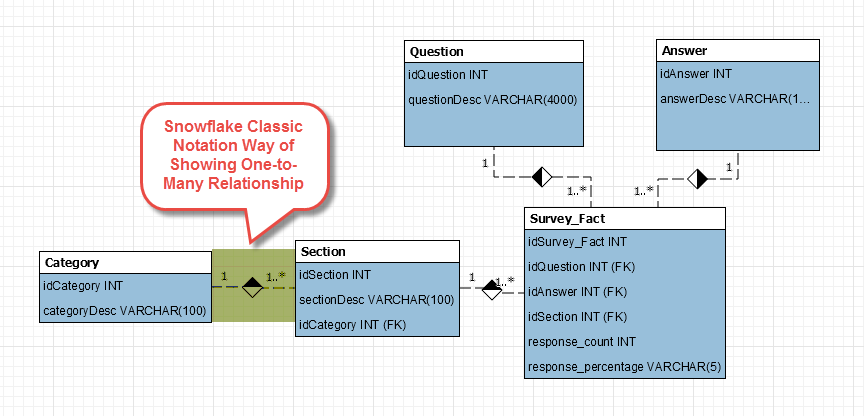

### Snowflake Schema - Connect to Columns Cardinality Notation

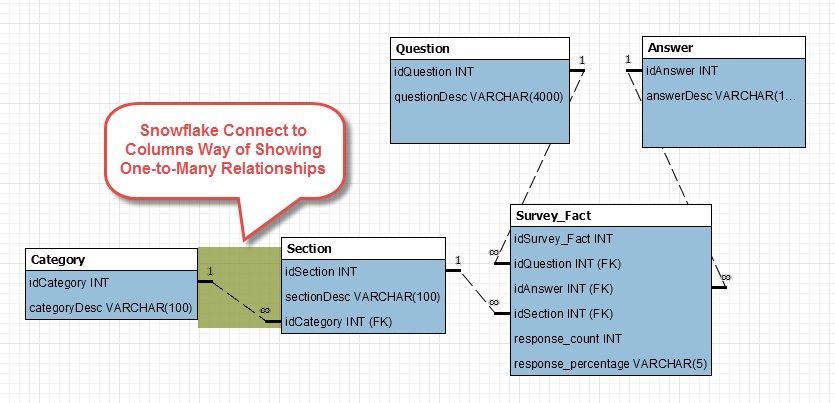

### Snowflake Schema - Unified Modeling Language Cardinality Notation (UML)

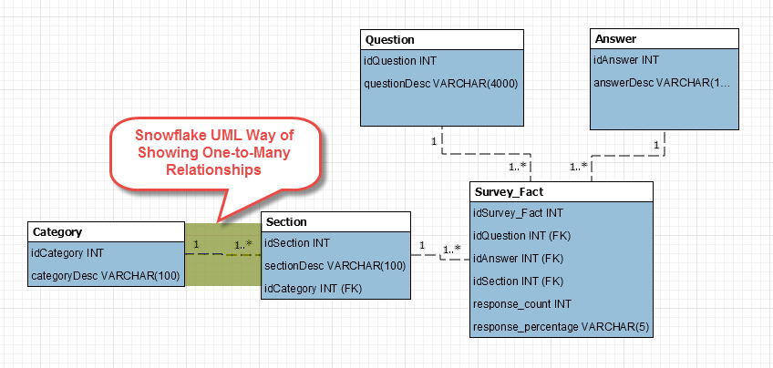

### Snowflake Schema - IDE1FX Cardinality Notation

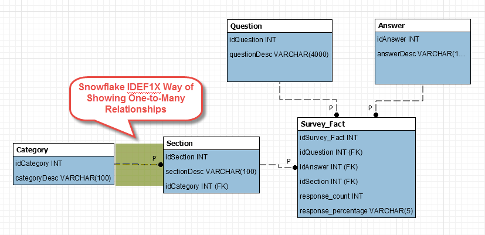